# R Notebook

```r
library(tidyverse)
```

1. Using the read_csv() function, read the GDP dataset into your notebook as a tibble called gdp_df. After reading it in, inspect the first 10 rows and then inspect the last 10 rows.

```r
gdp_df <- read_csv("../data/gdp_per_capita.csv")

head(gdp_df, 10)
```

| Country or Area | Year | Value | Value Footnotes |
| --- | --- | --- | --- |
| Afghanistan | 2021 | 1517.016 | NA |
| Afghanistan | 2020 | 1968.341 | NA |
| Afghanistan | 2019 | 2079.922 | NA |
| Afghanistan | 2018 | 2060.699 | NA |
| Afghanistan | 2017 | 2096.093 | NA |
| Afghanistan | 2016 | 2101.422 | NA |
| Afghanistan | 2015 | 2108.714 | NA |
| Afghanistan | 2014 | 2144.450 | NA |
| Afghanistan | 2013 | 2165.341 | NA |
| Afghanistan | 2012 | 2122.831 | NA |

```r
NA
```

```r
tail(gdp_df, 10)
```

| Country or Area | Year | Value | Value Footnotes |
| --- | --- | --- | --- |
| Zimbabwe | 1999 | 2866.033 | NA |
| Zimbabwe | 1998 | 2931.725 | NA |
| Zimbabwe | 1997 | 2896.147 | NA |
| Zimbabwe | 1996 | 2867.026 | NA |
| Zimbabwe | 1995 | 2641.378 | NA |
| Zimbabwe | 1994 | 2670.107 | NA |
| Zimbabwe | 1993 | 2458.783 | NA |
| Zimbabwe | 1992 | 2468.278 | NA |
| Zimbabwe | 1991 | 2781.788 | NA |
| Zimbabwe | 1990 | 2704.757 | NA |

2. Drop the ‘Value Footnotes’ column, and rename the remaining columns to ‘Country’, ‘Year’, and ‘GDP_Per_Capita’.

```r
gdp_df_drop <- gdp_df |>
  select(-`Value Footnotes`)


gdp_df_drop
```

| Country or Area | Year | Value |
| --- | --- | --- |
| Afghanistan | 2021 | 1517.0163 |
| Afghanistan | 2020 | 1968.3410 |
| Afghanistan | 2019 | 2079.9219 |
| Afghanistan | 2018 | 2060.6990 |
| Afghanistan | 2017 | 2096.0931 |
| Afghanistan | 2016 | 2101.4222 |
| Afghanistan | 2015 | 2108.7142 |
| Afghanistan | 2014 | 2144.4496 |
| Afghanistan | 2013 | 2165.3409 |
| Afghanistan | 2012 | 2122.8308 |

[output cut: 990 more lines]

```r
NA
```

```r
gdp_df_drop_rename <- gdp_df_drop |>
  rename(c(GDP_Per_Capita = Value, Country = `Country or Area`))

gdp_df_drop_rename
```

| Country | Year | GDP_Per_Capita |
| --- | --- | --- |
| Afghanistan | 2021 | 1517.0163 |
| Afghanistan | 2020 | 1968.3410 |
| Afghanistan | 2019 | 2079.9219 |
| Afghanistan | 2018 | 2060.6990 |
| Afghanistan | 2017 | 2096.0931 |
| Afghanistan | 2016 | 2101.4222 |
| Afghanistan | 2015 | 2108.7142 |
| Afghanistan | 2014 | 2144.4496 |
| Afghanistan | 2013 | 2165.3409 |
| Afghanistan | 2012 | 2122.8308 |

[output cut: 990 more lines]

3. Which years are represented in this dataset? How many observations are there per year? Make a plot to view the number of observations per year.

```r
min(gdp_df_drop_rename[,2])
```

```
[1] 1990
```

```r
max(gdp_df_drop_rename[,2])
```

```
[1] 2022
```

How many observations are there per year?

```r
no_obsv_year <- gdp_df_drop_rename |>
  count(Year)
no_obsv_year
```

| Year | n |
| --- | --- |
| 1990 | 207 |
| 1991 | 208 |
| 1992 | 210 |
| 1993 | 211 |
| 1994 | 213 |
| 1995 | 223 |
| 1996 | 223 |
| 1997 | 226 |
| 1998 | 226 |
| 1999 | 227 |

[output cut: 23 more lines]

Make a plot to view the number of observations per year.

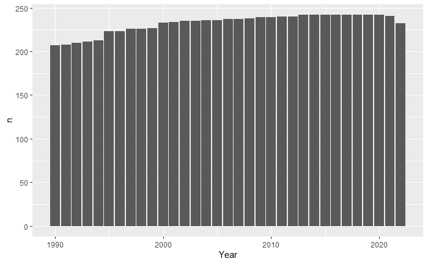

```r
no_obsv_year |>
  ggplot(aes(x = Year, y = n)) +
    geom_col()
```

4. How many countries are represented in this dataset? Which countries have the fewest observations?

```r
no_obsv_ctry <- gdp_df_drop_rename |>
  count(Country)
no_obsv_ctry
```

| Country | n |
| --- | --- |
| Afghanistan | 20 |
| Africa Eastern and Southern | 33 |
| Africa Western and Central | 33 |
| Albania | 33 |
| Algeria | 33 |
| Angola | 33 |
| Antigua and Barbuda | 33 |
| Arab World | 33 |
| Argentina | 33 |
| Armenia | 33 |

[output cut: 232 more lines]

```r
NA
```

```r
gdp_df_drop_rename |>
  distinct(Country[!is.na(Country)])
```

| Country[!is.na(Country)] |
| --- |
| Afghanistan |
| Africa Eastern and Southern |
| Africa Western and Central |
| Albania |
| Algeria |
| Angola |
| Antigua and Barbuda |
| Arab World |
| Argentina |
| Armenia |

[output cut: 232 more lines]

```r
gdp_df_drop_rename |>
  distinct(Country)
```

| Country |
| --- |
| Afghanistan |
| Africa Eastern and Southern |
| Africa Western and Central |
| Albania |
| Algeria |
| Angola |
| Antigua and Barbuda |
| Arab World |
| Argentina |
| Armenia |

[output cut: 232 more lines]

```r
NA
```

```r
length(unique(gdp_df_drop_rename$Country))
```

```
[1] 242
```

Which countries have the fewest observations?

```r
min(no_obsv_ctry$n)
```

```
[1] 10
```

```r
no_obsv_ctry |>
  mutate(freq = min(n))
```

| Country | n | freq |
| --- | --- | --- |
| Afghanistan | 20 | 10 |
| Africa Eastern and Southern | 33 | 10 |
| Africa Western and Central | 33 | 10 |
| Albania | 33 | 10 |
| Algeria | 33 | 10 |
| Angola | 33 | 10 |
| Antigua and Barbuda | 33 | 10 |
| Arab World | 33 | 10 |
| Argentina | 33 | 10 |
| Armenia | 33 | 10 |

[output cut: 232 more lines]

```r
NA
```

```r
tail(sort(no_obsv_ctry$Country), 3)
```

```
[1] "World"    "Zambia"   "Zimbabwe"
```

```r
with(unique(no_obsv_ctry[c("Country", "n")]), table(no_obsv_ctry))
```

```
                                                    n
Country                                              10 12 14 15 16 19 20 22 23 24 25 26 28 29 30 31 32 33
  Afghanistan                                         0  0  0  0  0  0  1  0  0  0  0  0  0  0  0  0  0  0
  Africa Eastern and Southern                         0  0  0  0  0  0  0  0  0  0  0  0  0  0  0  0  0  1
  Africa Western and Central                          0  0  0  0  0  0  0  0  0  0  0  0  0  0  0  0  0  1
  Albania                                             0  0  0  0  0  0  0  0  0  0  0  0  0  0  0  0  0  1
  Algeria                                             0  0  0  0  0  0  0  0  0  0  0  0  0  0  0  0  0  1
  Angola                                              0  0  0  0  0  0  0  0  0  0  0  0  0  0  0  0  0  1
  Antigua and Barbuda                                 0  0  0  0  0  0  0  0  0  0  0  0  0  0  0  0  0  1
  Arab World                                          0  0  0  0  0  0  0  0  0  0  0  0  0  0  0  0  0  1
  Argentina                                           0  0  0  0  0  0  0  0  0  0  0  0  0  0  0  0  0  1
  Armenia                                             0  0  0  0  0  0  0  0  0  0  0  0  0  0  0  0  0  1
  Aruba                                               0  0  0  0  0  0  0  0  0  0  0  0  0  0  0  0  1  0
  Australia                                           0  0  0  0  0  0  0  0  0  0  0  0  0  0  0  0  0  1
  Austria                                             0  0  0  0  0  0  0  0  0  0  0  0  0  0  0  0  0  1
  Azerbaijan                                          0  0  0  0  0  0  0  0  0  0  0  0  0  0  0  0  0  1
  Bahrain                                             0  0  0  0  0  0  0  0  0  0  0  0  0  0  0  0  0  1
  Bangladesh                                          0  0  0  0  0  0  0  0  0  0  0  0  0  0  0  0  0  1
  Barbados                                            0  0  0  0  0  0  0  0  0  0  0  0  0  0  0  0  0  1
  Belarus                                             0  0  0  0  0  0  0  0  0  0  0  0  0  0  0  0  0  1
  Belgium                                             0  0  0  0  0  0  0  0  0  0  0  0  0  0  0  0  0  1
  Belize                                              0  0  0  0  0  0  0  0  0  0  0  0  0  0  0  0  0  1
  Benin                                               0  0  0  0  0  0  0  0  0  0  0  0  0  0  0  0  0  1
  Bermuda                                             0  0  0  0  0  0  0  0  0  0  0  0  0  0  0  0  0  1
  Bhutan                                              0  0  0  0  0  0  0  0  0  0  0  0  0  0  0  0  1  0
  Bolivia                                             0  0  0  0  0  0  0  0  0  0  0  0  0  0  0  0  0  1
  Bosnia and Herzegovina                              0  0  0  0  0  0  0  0  0  0  0  0  0  1  0  0  0  0
  Botswana                                            0  0  0  0  0  0  0  0  0  0  0  0  0  0  0  0  0  1
  Brazil                                              0  0  0  0  0  0  0  0  0  0  0  0  0  0  0  0  0  1
  Brunei                                              0  0  0  0  0  0  0  0  0  0  0  0  0  0  0  0  0  1
  Bulgaria                                            0  0  0  0  0  0  0  0  0  0  0  0  0  0  0  0  0  1
  Burkina Faso                                        0  0  0  0  0  0  0  0  0  0  0  0  0  0  0  0  0  1
  Burundi                                             0  0  0  0  0  0  0  0  0  0  0  0  0  0  0  0  0  1
  CÃ´te d'Ivoire                                      0  0  0  0  0  0  0  0  0  0  0  0  0  0  0  0  0  1
  Cabo Verde                                          0  0  0  0  0  0  0  0  0  0  0  0  0  0  0  0  0  1
  Cambodia                                            0  0  0  0  0  0  0  0  0  0  0  0  0  0  1  0  0  0
  Cameroon                                            0  0  0  0  0  0  0  0  0  0  0  0  0  0  0  0  0  1
  Canada                                              0  0  0  0  0  0  0  0  0  0  0  0  0  0  0  0  0  1
```

[output cut: 20 more lines]

```r
table(gdp_df_drop_rename$Country)
```

```
                                       Afghanistan                        Africa Eastern and Southern                         Africa Western and Central
                                                20                                                 33                                                 33
                                           Albania                                            Algeria                                             Angola
                                                33                                                 33                                                 33
                               Antigua and Barbuda                                         Arab World                                          Argentina
                                                33                                                 33                                                 33
                                           Armenia                                              Aruba                                          Australia
                                                33                                                 32                                                 33
                                           Austria                                         Azerbaijan                                            Bahrain
                                                33                                                 33                                                 33
                                        Bangladesh                                           Barbados                                            Belarus
                                                33                                                 33                                                 33
                                           Belgium                                             Belize                                              Benin
                                                33                                                 33                                                 33
                                           Bermuda                                             Bhutan                                            Bolivia
                                                33                                                 32                                                 33
                            Bosnia and Herzegovina                                           Botswana                                             Brazil
                                                29                                                 33                                                 33
                                            Brunei                                           Bulgaria                                       Burkina Faso
                                                33                                                 33                                                 33
                                           Burundi                                     CÃ´te d'Ivoire                                         Cabo Verde
                                                33                                                 33                                                 33
                                          Cambodia                                           Cameroon                                             Canada
                                                30                                                 33                                                 33
                            Caribbean small states                                     Cayman Islands                           Central African Republic
                                                33                                                 16                                                 33
```

[output cut: 136 more lines]

```r
num_obsv_ctry <- gdp_df_drop_rename |>
  count(Country, sort = TRUE, name = "num_obsv_of_ctry")
tail(num_obsv_ctry)
```

| Country | num_obsv_of_ctry |
| --- | --- |
| Cayman Islands | 16 |
| Kosovo | 15 |
| Sint Maarten (Dutch part) | 14 |
| Turks and Caicos Islands | 12 |
| Djibouti | 10 |
| Somalia | 10 |

```r
NA
```

```r
lowest_num_obsrv_ctry <- num_obsv_ctry |>
  arrange(num_obsv_of_ctry) |>
  slice(1:5)
lowest_num_obsrv_ctry
```

| Country | num_obsv_of_ctry |
| --- | --- |
| Djibouti | 10 |
| Somalia | 10 |
| Turks and Caicos Islands | 12 |
| Sint Maarten (Dutch part) | 14 |
| Kosovo | 15 |

```r
min(num_obsv_ctry$num_obsv_of_ctry, na.rm = TRUE)
```

```
[1] 10
```

5. Create a new tibble by subsetting gdp_df to just the year 2021. Call this new tibble gdp_2021.

```r
gdp_2021 <- gdp_df_drop_rename |>
  filter(Year == "2021")

gdp_2021
```

| Country | Year | GDP_Per_Capita |
| --- | --- | --- |
| Afghanistan | 2021 | 1517.0163 |
| Africa Eastern and Southern | 2021 | 3519.1748 |
| Africa Western and Central | 2021 | 4014.6080 |
| Albania | 2021 | 14595.9444 |
| Algeria | 2021 | 11029.1388 |
| Angola | 2021 | 5911.8357 |
| Antigua and Barbuda | 2021 | 19899.8824 |
| Arab World | 2021 | 13745.2062 |
| Argentina | 2021 | 21527.1961 |
| Armenia | 2021 | 14193.1168 |

[output cut: 231 more lines]

```r
NA
```

```r
gdp_2021 |>
  count(Year)
```

| Year | n |
| --- | --- |
| 2021 | 241 |

```r
min(gdp_2021[,2])
```

```
[1] 2021
```

```r
max(gdp_2021[,2])
```

```
[1] 2021
```

6. Use summary() to find the summary statistics for GDP per capita in 2021.

```r
summary(gdp_2021$GDP_Per_Capita)
```

```
    Min.  1st Qu.   Median     Mean  3rd Qu.     Max.
   714.1   5044.2  13754.8  20711.6  30974.4 115683.5
```

```r
summary(gdp_2021)
```

```
   Country               Year      GDP_Per_Capita
 Length:241         Min.   :2021   Min.   :   714.1
 Class :character   1st Qu.:2021   1st Qu.:  5044.2
 Mode  :character   Median :2021   Median : 13754.8
                    Mean   :2021   Mean   : 20711.6
                    3rd Qu.:2021   3rd Qu.: 30974.4
                    Max.   :2021   Max.   :115683.5
```

7. Create a histogram of GDP Per Capita numbers for 2021 (you may wish to adjust the number of bins for your histogram).

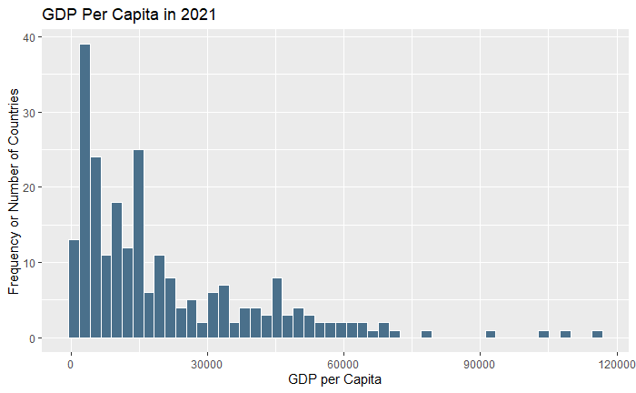

```r
ggplot( gdp_2021, aes( x= GDP_Per_Capita ) ) +
  geom_histogram( bins=50, color = "white", fill = "skyblue4" ) +
  labs(
    title = "GDP Per Capita in 2021",
    x = "GDP per Capita",
    y = "Frequency or Number of Countries"
  )
```

8. Find the top 5 counties and bottom 5 countries by GDP per capita in 2021.

```r
num_obsv_ctry_2021 <- gdp_2021 |>
  arrange(GDP_Per_Capita, sort = TRUE)

num_obsv_ctry_2021
```

| Country | Year | GDP_Per_Capita |
| --- | --- | --- |
| Burundi | 2021 | 714.0667 |
| Central African Republic | 2021 | 837.5047 |
| Dem. Rep. Congo | 2021 | 1073.6433 |
| Somalia | 2021 | 1136.7360 |
| Niger | 2021 | 1186.5768 |
| Mozambique | 2021 | 1226.7670 |
| Liberia | 2021 | 1423.2296 |
| Chad | 2021 | 1425.4945 |
| Madagascar | 2021 | 1482.3762 |
| Malawi | 2021 | 1491.1337 |

[output cut: 231 more lines]

```r
head(num_obsv_ctry_2021)
```

| Country | Year | GDP_Per_Capita |
| --- | --- | --- |
| Burundi | 2021 | 714.0667 |
| Central African Republic | 2021 | 837.5047 |
| Dem. Rep. Congo | 2021 | 1073.6433 |
| Somalia | 2021 | 1136.7360 |
| Niger | 2021 | 1186.5768 |
| Mozambique | 2021 | 1226.7670 |

```r
tail(num_obsv_ctry_2021)
```

| Country | Year | GDP_Per_Capita |
| --- | --- | --- |
| Switzerland | 2021 | 70097.37 |
| Bermuda | 2021 | 78570.49 |
| Qatar | 2021 | 92862.57 |
| Ireland | 2021 | 102785.49 |
| Singapore | 2021 | 107741.12 |
| Luxembourg | 2021 | 115683.49 |

```r
lowest_gdp_2021 <- num_obsv_ctry_2021 |>
  slice(1:5)

lowest_gdp_2021
```

| Country | Year | GDP_Per_Capita |
| --- | --- | --- |
| Burundi | 2021 | 714.0667 |
| Central African Republic | 2021 | 837.5047 |
| Dem. Rep. Congo | 2021 | 1073.6433 |
| Somalia | 2021 | 1136.7360 |
| Niger | 2021 | 1186.5768 |

```r
NA
```

```r
highest_gdp_2021 <- num_obsv_ctry_2021 |>
  slice(tail(row_number(), 5))

highest_gdp_2021
```

| Country | Year | GDP_Per_Capita |
| --- | --- | --- |
| Bermuda | 2021 | 78570.49 |
| Qatar | 2021 | 92862.57 |
| Ireland | 2021 | 102785.49 |
| Singapore | 2021 | 107741.12 |
| Luxembourg | 2021 | 115683.49 |

```r
NA
```

9. Now, return to the full dataset, gdp_df. Pivot the data for 1990 and 2021 (using pivot_wider() function) so that each row corresponds to a country, each column corresponds to a year, and the values in the table give the GDP_Per_Capita amount. Drop any rows that are missing values for either 1990 or 2021. Save the result to a tibble named gdp_pivoted.

```r
interim  <- gdp_df_drop_rename |>
  filter(Year == c(1990, 2021)) |>

  pivot_wider(
      names_from = Year,
      values_from = GDP_Per_Capita
    )
gdp_pivoted <- interim[complete.cases(interim), ]
gdp_pivoted
```

| Country | 2021 | 1990 |
| --- | --- | --- |
| Africa Eastern and Southern | 3519.175 | 3037.2975 |
| Albania | 14595.944 | 4827.0277 |
| Angola | 5911.836 | 5793.0845 |
| Arab World | 13745.206 | 9683.2279 |
| Armenia | 14193.117 | 5153.2982 |
| Aruba | 38866.333 | 30823.4825 |
| Austria | 54121.146 | 37494.5604 |
| Bahrain | 49754.048 | 36997.7356 |
| Barbados | 13754.802 | 14097.3955 |
| Belgium | 51823.508 | 35506.9265 |

[output cut: 93 more lines]

```r
NA
NA
```

10. Create a new column in gdp_pivoted named Percent_Change. This column should contain the percent change in GDP_Per_Capita from 1990 to 2021. Hint: Percent change is calculated as 100*(New Value - Old Value) / Old Value.

```r
gdp_pivoted$Percent_Change <- round(((gdp_pivoted$`2021` - gdp_pivoted$`1990`) / gdp_pivoted$`1990` )* 100, 4)
# gdp_pivoted$Percent_Change <- (((gdp_pivoted$`2021` - gdp_pivoted$`1990`) / gdp_pivoted$`1990` )* 100)
gdp_pivoted
```

| Country | 2021 | 1990 | Percent_Change |
| --- | --- | --- | --- |
| Africa Eastern and Southern | 3519.175 | 3037.2975 | 15.8653 |
| Albania | 14595.944 | 4827.0277 | 202.3795 |
| Angola | 5911.836 | 5793.0845 | 2.0499 |
| Arab World | 13745.206 | 9683.2279 | 41.9486 |
| Armenia | 14193.117 | 5153.2982 | 175.4181 |
| Aruba | 38866.333 | 30823.4825 | 26.0933 |
| Austria | 54121.146 | 37494.5604 | 44.3440 |
| Bahrain | 49754.048 | 36997.7356 | 34.4786 |
| Barbados | 13754.802 | 14097.3955 | -2.4302 |
| Belgium | 51823.508 | 35506.9265 | 45.9532 |

[output cut: 93 more lines]

11. How many countries experienced a negative percent change in GDP per capita from 1990 to 2021? Nine (9) countries experienced a negative percent change in GDP per capita from 1990 to 2021.

```r
gdp_pivoted[gdp_pivoted[4] < 0, ]
```

| Country | 2021 | 1990 | Percent_Change |
| --- | --- | --- | --- |
| Barbados | 13754.802 | 14097.396 | -2.4302 |
| Brunei | 60127.024 | 70358.724 | -14.5422 |
| Congo | 3234.393 | 5007.319 | -35.4067 |
| Dem. Rep. Congo | 1073.643 | 1750.170 | -38.6549 |
| Kiribati | 2007.987 | 2045.272 | -1.8230 |
| Kyrgyz Republic | 4933.786 | 5158.318 | -4.3528 |
| Madagascar | 1482.376 | 1808.744 | -18.0439 |
| The Bahamas | 30053.032 | 35674.456 | -15.7576 |
| United Arab Emirates | 69733.794 | 105893.626 | -34.1473 |

```r
NA
```

12. Which country had the highest % change in GDP per capita? Create a line plot showing these country’s GDP per capita for all years for which you have data. Put both line charts on the same plot.

```r
gdp_pivoted[which.max(gdp_pivoted$Percent_Change),]
```

| Country | 2021 | 1990 | Percent_Change |
| --- | --- | --- | --- |
| East Asia & Pacific (excluding high income) | 15415.45 | 2191.972 | 603.2684 |

```r
gdp_pivoted |>
    arrange(desc(Percent_Change)) |>
    slice(1:5)
```

| Country | 2021 | 1990 | Percent_Change |
| --- | --- | --- | --- |
| East Asia & Pacific (excluding high income) | 15415.448 | 2191.972 | 603.2684 |
| Guyana | 21925.187 | 4818.388 | 355.0316 |
| Late-demographic dividend | 18541.056 | 5302.384 | 249.6739 |
| South Asia | 6361.381 | 1963.245 | 224.0238 |
| Albania | 14595.944 | 4827.028 | 202.3795 |

```r
NA
```

Create a line plot showing these country’s GDP per capita for all years for which you have data.

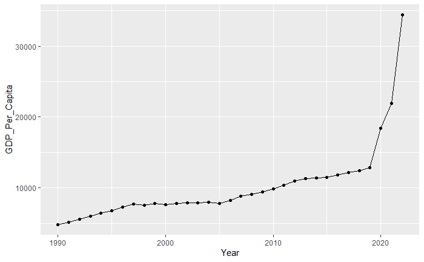

```r
gdp_guyana  <- gdp_df_drop_rename |>
  filter(Country == "Guyana")

ggplot(data=gdp_guyana, aes(x=Year, y=GDP_Per_Capita, group=1)) +
  geom_line()+
  geom_point()
```

```r
gdp_guyana
```

| Country | Year | GDP_Per_Capita |
| --- | --- | --- |
| Guyana | 2022 | 34420.068 |
| Guyana | 2021 | 21925.187 |
| Guyana | 2020 | 18430.570 |
| Guyana | 2019 | 12820.490 |
| Guyana | 2018 | 12374.220 |
| Guyana | 2017 | 12193.622 |
| Guyana | 2016 | 11819.155 |
| Guyana | 2015 | 11446.763 |
| Guyana | 2014 | 11427.873 |
| Guyana | 2013 | 11293.950 |

[output cut: 23 more lines]

```r
NA
```

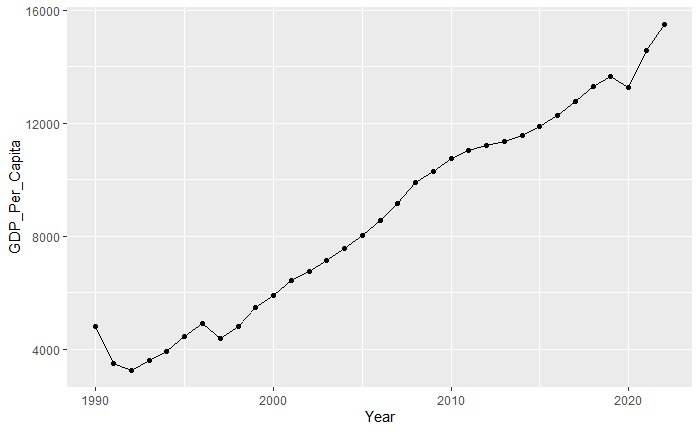

```r
gdp_albania  <- gdp_df_drop_rename |>
  filter(Country == "Albania")

ggplot(data=gdp_albania, aes(x=Year, y=GDP_Per_Capita, group=1)) +
  geom_line() +
  geom_point()
```

```r
gdp_albania
```

| Country | Year | GDP_Per_Capita |
| --- | --- | --- |
| Albania | 2022 | 15501.663 |
| Albania | 2021 | 14595.944 |
| Albania | 2020 | 13278.370 |
| Albania | 2019 | 13653.182 |
| Albania | 2018 | 13317.119 |
| Albania | 2017 | 12770.992 |
| Albania | 2016 | 12291.842 |
| Albania | 2015 | 11878.438 |
| Albania | 2014 | 11586.817 |
| Albania | 2013 | 11361.252 |

[output cut: 23 more lines]

```r
NA
```

Put both line charts on the same plot.

```r
gdp_albania
```

| Country | Year | GDP_Per_Capita |
| --- | --- | --- |
| Albania | 2022 | 15501.663 |
| Albania | 2021 | 14595.944 |
| Albania | 2020 | 13278.370 |
| Albania | 2019 | 13653.182 |
| Albania | 2018 | 13317.119 |
| Albania | 2017 | 12770.992 |
| Albania | 2016 | 12291.842 |
| Albania | 2015 | 11878.438 |
| Albania | 2014 | 11586.817 |
| Albania | 2013 | 11361.252 |

[output cut: 23 more lines]

```r
gdp_guyana
```

| Country | Year | GDP_Per_Capita |
| --- | --- | --- |
| Guyana | 2022 | 34420.068 |
| Guyana | 2021 | 21925.187 |
| Guyana | 2020 | 18430.570 |
| Guyana | 2019 | 12820.490 |
| Guyana | 2018 | 12374.220 |
| Guyana | 2017 | 12193.622 |
| Guyana | 2016 | 11819.155 |
| Guyana | 2015 | 11446.763 |
| Guyana | 2014 | 11427.873 |
| Guyana | 2013 | 11293.950 |

[output cut: 23 more lines]

```r
plot(gdp_albania$Year, gdp_albania$GDP_Per_Capita,
     main = "GDP Per Capita Albania and Guyana 1990-2021",
     xlab = "Years",
     ylab = "GDP Per Capita",
     type = "l",
     ylim = c(0, 35000)
     )
#
lines(gdp_guyana$Year, gdp_guyana$GDP_Per_Capita,
      lty = "dashed")
```

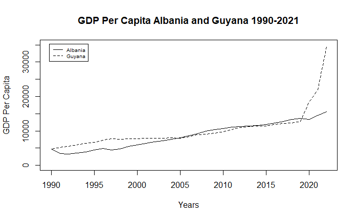

```r
#
labels <- c("Albania", "Guyana")
#
legend("topleft", legend = labels,
       cex = 0.6,
       inset = 0.03,
       pch = NULL,
       lty = c(1, 2))
```

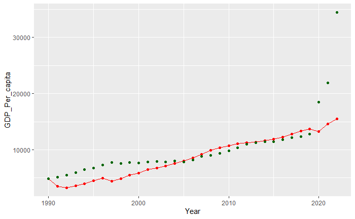

```r
ggplot(data=gdp_albania, aes(x=Year, y=GDP_Per_Capita, group=1)) +
  geom_line(color="red")+
  geom_point(color="red")+
  labs(x = "Year", y = "GDP_Per_capita") +
  geom_point(data=gdp_guyana, color="darkgreen", aes(x=Year, y=GDP_Per_Capita, group=1) +
  geom_line(color="darkgreen")
             )
```

13. Read in continents.csv contained in the data folder into a new tibble called continents. We will be using this tibble to add a new column to our dataset.

```r
continents <- read_csv("../data/continents.csv")


continents
```

| Continent | Country |
| --- | --- |
| Asia | Afghanistan |
| Europe | Albania |
| Africa | Algeria |
| Europe | Andorra |
| Africa | Angola |
| North America | Antigua and Barbuda |
| South America | Argentina |
| Europe | Armenia |
| North America | Aruba |
| Oceania | Australia |

[output cut: 206 more lines]

```r
# head(continents, 10)
```

14. Merge gdp_df and continents. Keep only the countries that appear in both data frames. Save the result back to gdp_df.

```r
gdp_df <- merge(gdp_df_drop_rename, continents, by="Country")
gdp_df
```

| Country | Year | GDP_Per_Capita | Continent |
| --- | --- | --- | --- |
| Afghanistan | 2006 | 1366.9931 | Asia |
| Afghanistan | 2021 | 1517.0163 | Asia |
| Afghanistan | 2015 | 2108.7142 | Asia |
| Afghanistan | 2004 | 1260.0606 | Asia |
| Afghanistan | 2016 | 2101.4222 | Asia |
| Afghanistan | 2005 | 1352.3206 | Asia |
| Afghanistan | 2011 | 1961.0963 | Asia |
| Afghanistan | 2017 | 2096.0931 | Asia |
| Afghanistan | 2003 | 1292.3334 | Asia |
| Afghanistan | 2012 | 2122.8308 | Asia |

[output cut: 990 more lines]

15. Determine the number of countries per continent. Create a bar chart showing this.

```r
num_continents <- gdp_df |>
  group_by(Continent) |>
  summarise(Num_Countries_per_Continent = n_distinct(Country))

num_continents
```

| Continent | Num_Countries_per_Continent |
| --- | --- |
| Africa | 50 |
| Asia | 41 |
| Europe | 44 |
| North America | 26 |
| Oceania | 14 |
| South America | 11 |

```r
NA
```

16. Create a boxplot showing GDP per capita in 2021 split out by continent. What do you notice?

```r
gdp_df_2021_continents  <- gdp_df |>
  filter(Year == 2021)

gdp_df_2021_continents
```

| Country | Year | GDP_Per_Capita | Continent |
| --- | --- | --- | --- |
| Afghanistan | 2021 | 1517.0163 | Asia |
| Albania | 2021 | 14595.9444 | Europe |
| Algeria | 2021 | 11029.1388 | Africa |
| Angola | 2021 | 5911.8357 | Africa |
| Antigua and Barbuda | 2021 | 19899.8824 | North America |
| Argentina | 2021 | 21527.1961 | South America |
| Armenia | 2021 | 14193.1168 | Europe |
| Aruba | 2021 | 38866.3335 | North America |
| Australia | 2021 | 49774.3407 | Oceania |
| Austria | 2021 | 54121.1455 | Europe |

[output cut: 175 more lines]

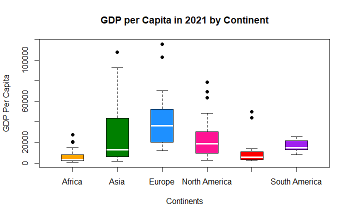

```r
my_colors <- c("#FFA500", "#008000", "#1E90FF", "#FF1493", "red", "purple")

boxplot(GDP_Per_Capita ~ Continent, data = gdp_df_2021_continents,
      main = "GDP per Capita in 2021 by Continent", xlab = "Continents", ylab = "GDP Per Capita",
      col = my_colors, border = "black", notch = FALSE, notchwidth = 0.5,
      medcol = "white", whiskcol = "black", boxwex = 0.5, outpch = 19,
      outcol = "black"
      )
```

```r
# text(seq_along(unique(gdp_df_2021_continents$Continent)), par("usr")[3],
#     labels = seq_along(unique(gdp_df_2021_continents$Continent)), srt = 45, adj = c(1.1, 1.1), xpd = TRUE)
```

```r
#
# boxplot(GDP_Per_Capita ~ Continent, data = gdp_df_2021_continents, pars  =  list(xaxt = "n"))
# axis(2, at=gdp_df_2021_continents$Continent, labels = TRUE)
# text(y = seq(0, 100, by=20), par("usr")[1], labels = lablist.y, srt = 45, pos = 2, xpd = TRUE)
# # axis(1, at=c(1,2), labels = FALSE)
# text(c(1:6), par("usr")[3] - 1, labels = gdp_df_2021_continents$Continent, srt = 45, pos = 1, xpd = TRUE)
# text(y = seq(1, 6, by=20), par("usr")[1], labels = gdp_df_2021_continents$Continents, srt = 45, pos = 1, xpd = TRUE)
```

17. Read life_expectancy.csv into a tibble named life_expectancy. Do not modify the csv file in order to read this data in.

```r
life_expectancy <- read_csv("../data/life_expectancy.csv")


life_expectancy
```

[output not shown]

[output cut: 258 more lines]

```r
NA
```